# Vihno Verde - EDA by Adam Klimiuk

> Vinho Verde is by far my most favorite wine, especially white variety.

Input variables (based on physicochemical tests): 1 - fixed acidity (tartaric acid - g / dm^3) 2 - volatile acidity (acetic acid - g / dm^3) 3 - citric acid (g / dm^3) 4 - residual sugar (g / dm^3) 5 - chlorides (sodium chloride - g / dm^3 6 - free sulfur dioxide (mg / dm^3) 7 - total sulfur dioxide (mg / dm^3) 8 - density (g / cm^3) 9 - pH 10 - sulphates (potassium sulphate - g / dm3) 11 - alcohol (% by volume) Output variable (based on sensory data): 12 - quality (score between 0 and 10)

# Univariate Plots Section

## Data structure exploration

```
## [1] 4898   13
```

This dataset includes 13 variables with 4898 observations.

```
## 'data.frame':    4898 obs. of  13 variables:
##  $ X                   : int  1 2 3 4 5 6 7 8 9 10 ...
##  $ fixed.acidity       : num  7 6.3 8.1 7.2 7.2 8.1 6.2 7 6.3 8.1 ...
##  $ volatile.acidity    : num  0.27 0.3 0.28 0.23 0.23 0.28 0.32 0.27 0.3 0.22 ...
##  $ citric.acid         : num  0.36 0.34 0.4 0.32 0.32 0.4 0.16 0.36 0.34 0.43 ...
##  $ residual.sugar      : num  20.7 1.6 6.9 8.5 8.5 6.9 7 20.7 1.6 1.5 ...
##  $ chlorides           : num  0.045 0.049 0.05 0.058 0.058 0.05 0.045 0.045 0.049 0.044 ...
##  $ free.sulfur.dioxide : num  45 14 30 47 47 30 30 45 14 28 ...
##  $ total.sulfur.dioxide: num  170 132 97 186 186 97 136 170 132 129 ...
##  $ density             : num  1.001 0.994 0.995 0.996 0.996 ...
##  $ pH                  : num  3 3.3 3.26 3.19 3.19 3.26 3.18 3 3.3 3.22 ...
##  $ sulphates           : num  0.45 0.49 0.44 0.4 0.4 0.44 0.47 0.45 0.49 0.45 ...
##  $ alcohol             : num  8.8 9.5 10.1 9.9 9.9 10.1 9.6 8.8 9.5 11 ...
##  $ quality             : int  6 6 6 6 6 6 6 6 6 6 ...
```

```r
summary(verde)
```

```
##        X        fixed.acidity    volatile.acidity  citric.acid
##  Min.   :   1   Min.   : 3.800   Min.   :0.0800   Min.   :0.0000
##  1st Qu.:1225   1st Qu.: 6.300   1st Qu.:0.2100   1st Qu.:0.2700
##  Median :2450   Median : 6.800   Median :0.2600   Median :0.3200
##  Mean   :2450   Mean   : 6.855   Mean   :0.2782   Mean   :0.3342
##  3rd Qu.:3674   3rd Qu.: 7.300   3rd Qu.:0.3200   3rd Qu.:0.3900
##  Max.   :4898   Max.   :14.200   Max.   :1.1000   Max.   :1.6600
##  residual.sugar     chlorides       free.sulfur.dioxide
##  Min.   : 0.600   Min.   :0.00900   Min.   :  2.00
##  1st Qu.: 1.700   1st Qu.:0.03600   1st Qu.: 23.00
##  Median : 5.200   Median :0.04300   Median : 34.00
##  Mean   : 6.391   Mean   :0.04577   Mean   : 35.31
##  3rd Qu.: 9.900   3rd Qu.:0.05000   3rd Qu.: 46.00
##  Max.   :65.800   Max.   :0.34600   Max.   :289.00
##  total.sulfur.dioxide    density             pH          sulphates
##  Min.   :  9.0        Min.   :0.9871   Min.   :2.720   Min.   :0.2200
##  1st Qu.:108.0        1st Qu.:0.9917   1st Qu.:3.090   1st Qu.:0.4100
##  Median :134.0        Median :0.9937   Median :3.180   Median :0.4700
##  Mean   :138.4        Mean   :0.9940   Mean   :3.188   Mean   :0.4898
##  3rd Qu.:167.0        3rd Qu.:0.9961   3rd Qu.:3.280   3rd Qu.:0.5500
##  Max.   :440.0        Max.   :1.0390   Max.   :3.820   Max.   :1.0800
##     alcohol         quality
##  Min.   : 8.00   Min.   :3.000
##  1st Qu.: 9.50   1st Qu.:5.000
##  Median :10.40   Median :6.000
##  Mean   :10.51   Mean   :5.878
##  3rd Qu.:11.40   3rd Qu.:6.000
##  Max.   :14.20   Max.   :9.000
```

Column X is contains order numbers, can be removed.

```r
verde <- subset(verde,select = -c(X))
```

Based on the initial data description, vatiable ‘quality’ is a categorical parameter. In this dataset it’s represented as integer, so I am going to convert it to a factor.

```r
verde$quality <- factor(verde$quality)
```

### New columns

Apart from quality, the remaining categories have continuous values. Column X is a counter and will not be considered in the analysis. Citric.acid has minimum value of 0, which may be an error.

Also, since wines are usually classified based on their sweetnes. An excellent guide how to assess sweetness of wine, depending on pH, sugar and acid content. https://drinkriesling.com/tasteprofile/thescale

```r
#  sugar/acid ratio
verde$sugar_acid.ratio <- verde$residual.sugar/(verde$fixed.acidity +
                                                  verde$volatile.acidity +
                                                  verde$citric.acid)
```

```r
verde$sweetnes <- with (verde, ifelse(sugar_acid.ratio<1
                                      ,ifelse(pH<3.1,"Extra Dry"
                                             ,ifelse(pH<3.3,"Dry"
                                                    ,ifelse(pH<3.5,"Medium Dry","Medium Sweet")
                                                    )
                                             )
                                      ,ifelse(sugar_acid.ratio<=2
                                              ,ifelse(pH<=2.9,"Dry"
                                                     ,ifelse(pH<3.3,"Medium Dry","Medium Sweet")
                                                     )
                                              ,ifelse(sugar_acid.ratio<4.1
                                                      ,ifelse(pH<=2.8,"Dry"
                                                             ,ifelse(pH<=2.9,"Medium Dry"
                                                                    ,ifelse(pH<3.3,"Medium Sweet","Sweet")
                                                                    )
                                                             )
                                                      ,ifelse(pH<=2.8,"Medium Dry"
                                                              ,ifelse(pH<=2.9,"Medium Sweet","Sweet")
                                                              )
                                                      )
                                              )
                                      )
                        )
```

```
##    Min. 1st Qu.  Median    Mean 3rd Qu.    Max.
## 0.06459 0.23495 0.72251 0.85776 1.28738 7.02616
```

```
##    Extra Dry          Dry   Medium Dry Medium Sweet        Sweet
##          710         1576         1923          635           54
```

### Initial plots

For a quick overview I am going to plot all columns using qplot in a loop. The advantage of using qplot is that it will decide by itself if to plot histogram or bar chart depenting on input data.

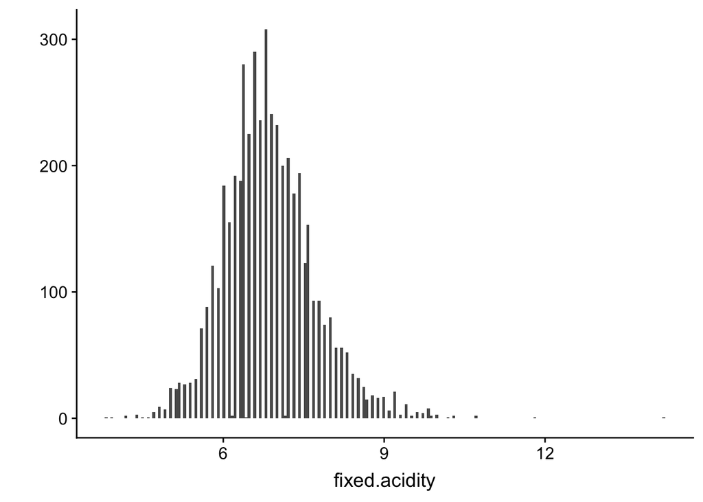

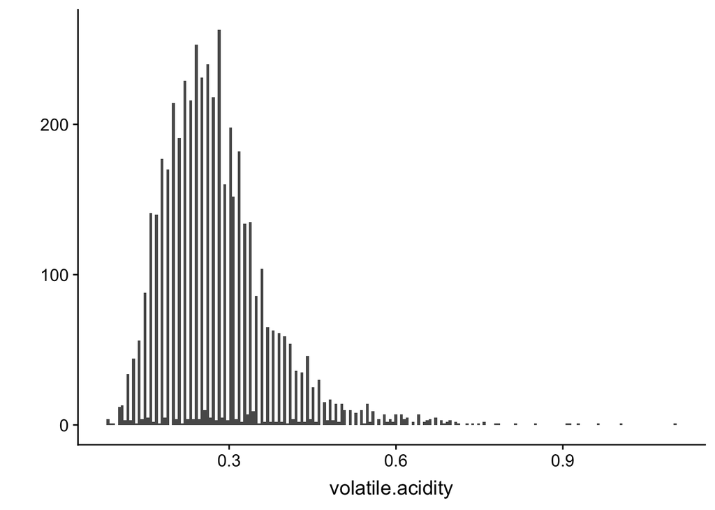

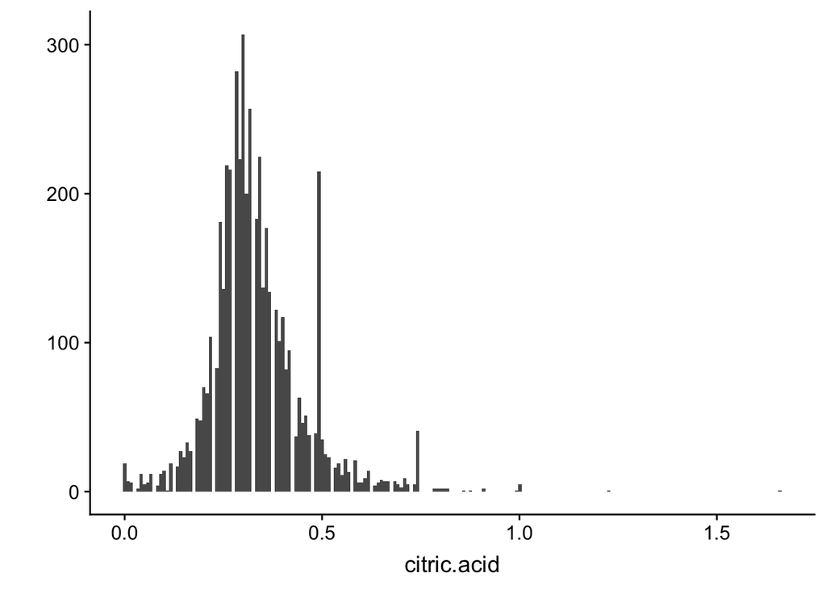

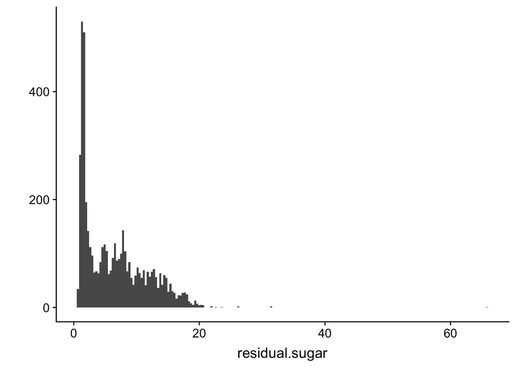

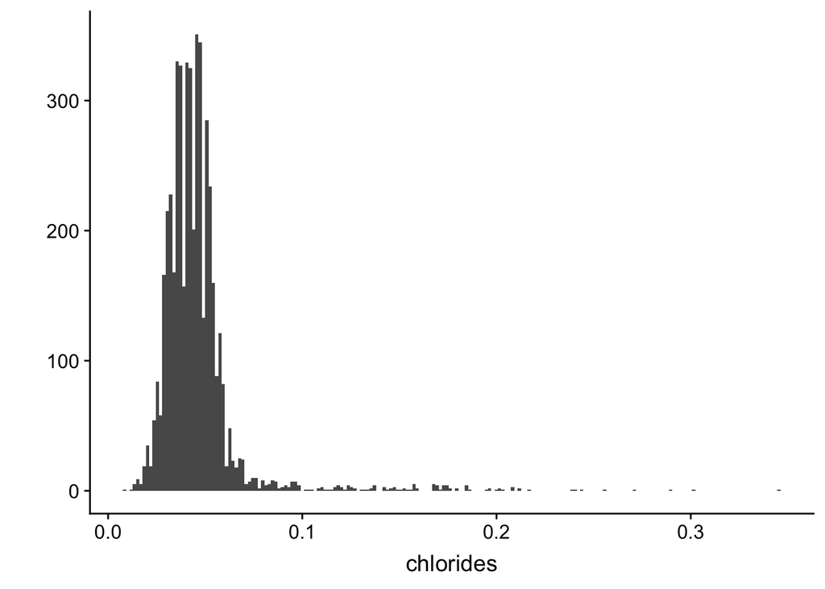

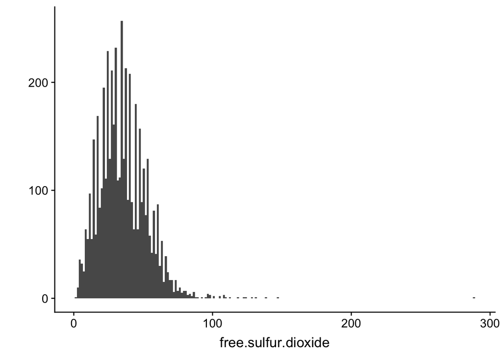

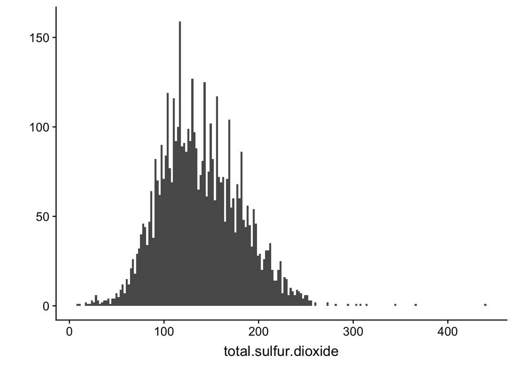

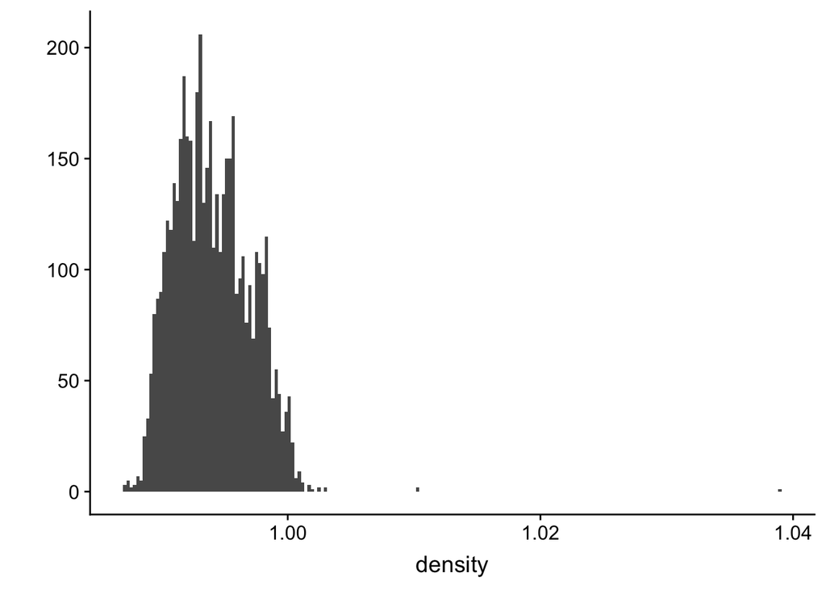

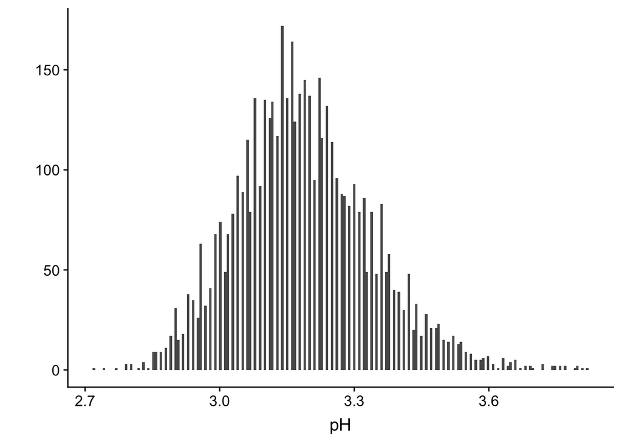

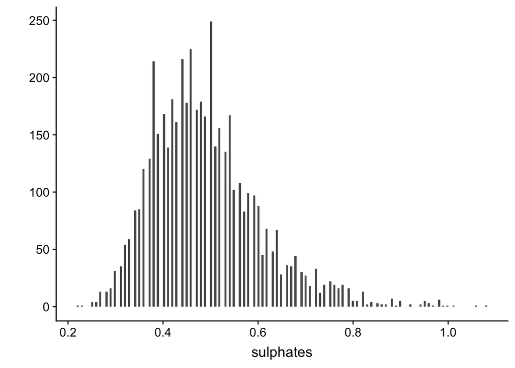

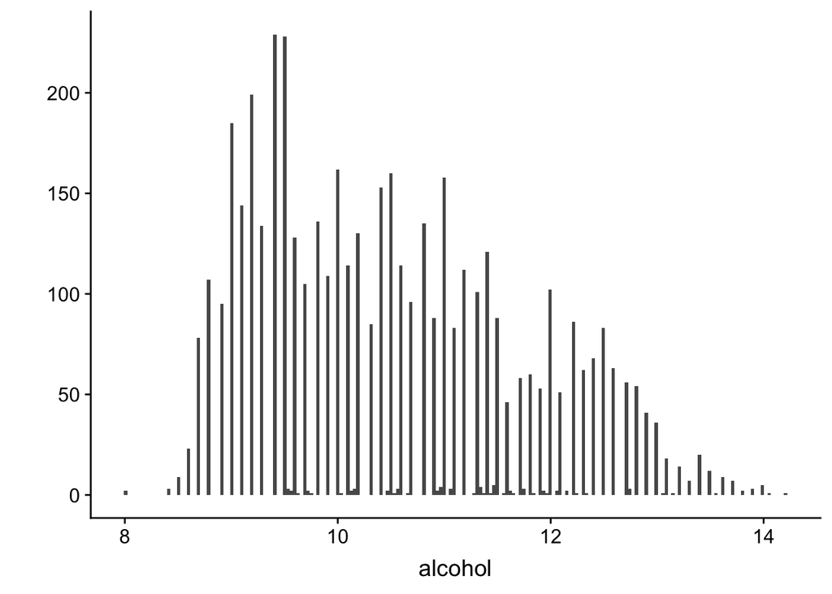

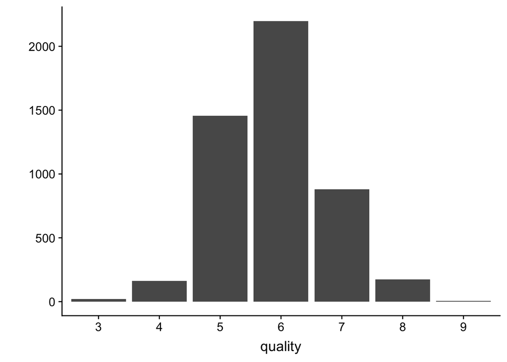

[2 more figures not shown]

```r
for (i in names(verde)){
  print(qplot(data = verde, verde[,i], xlab=i, bins=200))
}
```